# Iris: Data Manipulation + Visualization

Edgar Anderson’s Iris Data Description This famous (Fisher’s or Anderson’s) iris data set gives the measurements in centimeters of the variables sepal length and width and petal length and width, respectively, for 50 flowers from each of 3 species of iris. The species are Iris setosa, versicolor, and virginica.

```r
iris
```

|  | Sepal.Length | Sepal.Width | Petal.Length | Petal.Width | Species |
| --- | --- | --- | --- | --- | --- |
| 1 | 5.1 | 3.5 | 1.4 | 0.2 | setosa |
| 2 | 4.9 | 3.0 | 1.4 | 0.2 | setosa |
| 3 | 4.7 | 3.2 | 1.3 | 0.2 | setosa |
| 4 | 4.6 | 3.1 | 1.5 | 0.2 | setosa |
| 5 | 5.0 | 3.6 | 1.4 | 0.2 | setosa |
| 6 | 5.4 | 3.9 | 1.7 | 0.4 | setosa |
| 7 | 4.6 | 3.4 | 1.4 | 0.3 | setosa |
| 8 | 5.0 | 3.4 | 1.5 | 0.2 | setosa |
| 9 | 4.4 | 2.9 | 1.4 | 0.2 | setosa |
| 10 | 4.9 | 3.1 | 1.5 | 0.1 | setosa |

[output cut: 140 more lines]

```r
head(iris)
```

|  | Sepal.Length | Sepal.Width | Petal.Length | Petal.Width | Species |
| --- | --- | --- | --- | --- | --- |
| 1 | 5.1 | 3.5 | 1.4 | 0.2 | setosa |
| 2 | 4.9 | 3.0 | 1.4 | 0.2 | setosa |
| 3 | 4.7 | 3.2 | 1.3 | 0.2 | setosa |
| 4 | 4.6 | 3.1 | 1.5 | 0.2 | setosa |
| 5 | 5.0 | 3.6 | 1.4 | 0.2 | setosa |
| 6 | 5.4 | 3.9 | 1.7 | 0.4 | setosa |

```r
str(iris)
```

```
'data.frame':   150 obs. of  5 variables:
 $ Sepal.Length: num  5.1 4.9 4.7 4.6 5 5.4 4.6 5 4.4 4.9 ...
 $ Sepal.Width : num  3.5 3 3.2 3.1 3.6 3.9 3.4 3.4 2.9 3.1 ...
 $ Petal.Length: num  1.4 1.4 1.3 1.5 1.4 1.7 1.4 1.5 1.4 1.5 ...
 $ Petal.Width : num  0.2 0.2 0.2 0.2 0.2 0.4 0.3 0.2 0.2 0.1 ...
 $ Species     : chr  "setosa" "setosa" "setosa" "setosa" ...
```

```r
#libraries:
library(MASS)
library(dplyr)
library(ggplot2)
library(magrittr) #%>% operator
library(tidyr)
```

iris is a data frame with 150 cases (rows) and 5 variables (columns) named Sepal.Length, Sepal.Width, Petal.Length, Petal.Width, and Species. We rearrange columns for better aesthetics of the data, and it would be helpful when we tidy data.

```r
str(iris.tidy)
```

```
'data.frame':   600 obs. of  4 variables:
 $ Species: chr  "setosa" "setosa" "setosa" "setosa" ...
 $ Part   : chr  "Sepal" "Sepal" "Sepal" "Sepal" ...
 $ Measure: chr  "Length" "Length" "Length" "Length" ...
 $ Value  : num  5.1 4.9 4.7 4.6 5 5.4 4.6 5 4.4 4.9 ...
```

```r
library(dplyr)
library(magrittr)

#import data
iris<-read.csv("datasets/iris.csv")
#Separating sepal data
iris1a<-iris %>%
  mutate(Part="Sepal") %>%
  select(Species,Part,Sepal.Length,Sepal.Width) %>%
  rename(Length=Sepal.Length,Width=Sepal.Width)
#Separating petal data
iris1b<-iris %>%
  mutate(Part="Petal") %>%
  select(Species,Part,Petal.Length,Petal.Width) %>%
  rename(Length=Petal.Length,Width=Petal.Width)
#Combining sepal and petal data
iris2<-rbind(iris1a,iris1b)
iris2a<-iris2 %>%
  mutate(Measure="Length") %>%
  select(Species,Part,Measure,Length) %>%
  rename(Value=Length)
iris2b<-iris2 %>%
  mutate(Measure="Width") %>%
  select(Species,Part,Measure,Width) %>%
  rename(Value=Width)
iris3<-rbind(iris2a,iris2b)
```

Now, we are at the step where we visualize the data we cleaned. The data interpretation can be difficult in the following graph as we can’t really interpret anything useful.

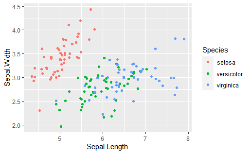

```r
ggplot(data = iris,aes(x=Sepal.Length,y=Sepal.Width,col=Species))+
  geom_jitter()
```

The second graph is more visually pleasing as there isn’t a mix up of different species and we can even conclude a strong correlation for measure of Petals depending on the species.

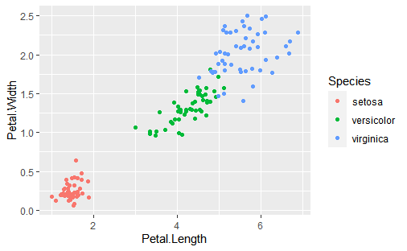

```r
ggplot(data = iris,aes(x=Petal.Length,y=Petal.Width,col=Species))+
  geom_jitter()
```

The plots in the graphs aren’t accurate because we used the function geom_jitter Funtion geom_point() maps the data as it is, but geom_jitter() adds a little variance to data for better representation in several cases and avoid overlapping of same values.

In the next graph we are going to use a function facet_grid() which would make the visualization experience more aesthetic and easier to interpret.

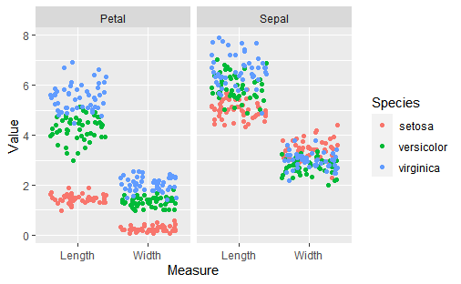

```r
ggplot(data=iris.tidy,aes(x=Measure,y=Value,col=Species))+
  geom_jitter()+
  facet_grid(.~Part)
```